```python
from IPython.display import HTML

HTML(
'''
<script>
    code_show=false;
    function code_toggle() {
         if (!code_show){
             $('div.input').hide();
         } else {
             $('div.input').show();
         }
         code_show = !code_show
        }
        $(document).ready(code_toggle);
</script>

<form action="javascript:code_toggle()">
    <input type="submit" value="Show code">
</form>
'''
)
```

# Basic Stock Market Analysis

## Analysis of Tesla, Ford, and GM stocks from 2012-2017 period

- Data
  - Opening Prices
  - Volume Traded Each Day
  - Total Money Traded Each Day
  - Moving Averages
  - Scatter Matrix of Open Prices
  - Candlesticks
- Basic Financial Analysis
  - Daily Percentage Change
  - Kernel Density Estimation
  - Box Plots
  - Scatter Matrix of Daily Returns

```python
import numpy as np
import pandas as pd
import pandas_datareader
from datetime import datetime
import matplotlib.pyplot as plt
import pandas_datareader.data as web
```

```python
plt.rcParams['font.size'] = 20
```

## Data

**TESLA**, **Ford**, and **GM** *2012-2017* ticks. Obtained using Pandas Datareader with Yahoo API.

```python
start = datetime(2012, 1, 1)
end = datetime(2017, 1, 1)
```

```python
tesla_ticks = web.DataReader('TSLA', 'yahoo', start, end)
```

```python
ford_ticks = web.DataReader('F', 'yahoo', start, end)
```

```python
gm_ticks = web.DataReader('GM', 'yahoo', start, end)
```

### Opening prices

back to index

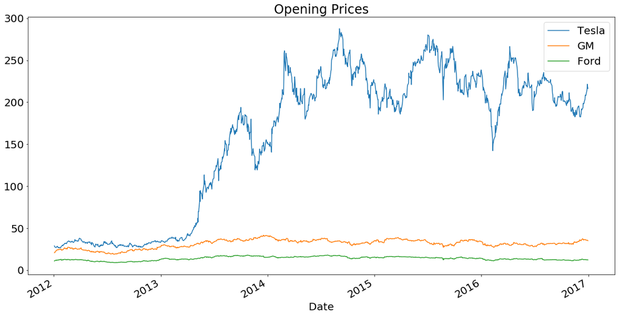

```python
tesla_ticks['Open'].plot(
    label='Tesla',
    figsize=(20, 10),
    title='Opening Prices'
)

gm_ticks['Open'].plot(label='GM')

ford_ticks['Open'].plot(label='Ford')

plt.legend();
```

### Volume of stock traded each day

back to index

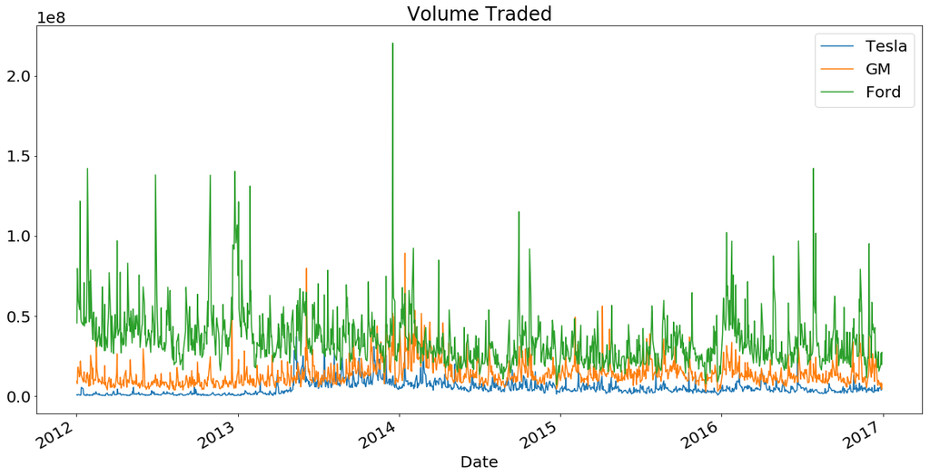

```python
tesla_ticks['Volume'].plot(
    label='Tesla',
    figsize=(20, 10),
    title='Volume Traded'
)

gm_ticks['Volume'].plot(label='GM')

ford_ticks['Volume'].plot(label='Ford')

plt.legend();
```

#### There is a big spike in the volume of Ford stocks traded sometime in late 2013

```python
ford_ticks['Volume'].idxmax()
```

```
Timestamp('2013-12-18 00:00:00')
```

#### Reason for the spike

[Aggressive Ford plans to hit profits, shares fall](http://money.cnn.com/2013/12/18/news/companies/ford-profit/index.html)

### Total Traded

Not a Market Cap. Crude estimation.

back to index

```python
for df in [tesla_ticks, ford_ticks, gm_ticks]:
    df['Total Traded'] = df['Open'] * df['Volume']
```

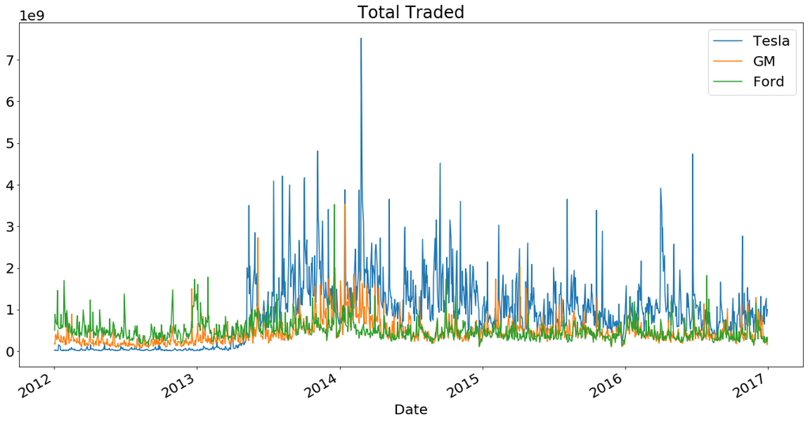

```python
tesla_ticks['Total Traded'].plot(
    label='Tesla',
    figsize=(20, 10),
    title='Total Traded'
)

gm_ticks['Total Traded'].plot(label='GM')

ford_ticks['Total Traded'].plot(label='Ford')

plt.legend();
```

#### There was a huge amount of money traded for Tesla sometime in early 2014

```python
tesla_ticks['Total Traded'].idxmax()
```

```
Timestamp('2014-02-25 00:00:00')
```

#### Reason for this was Morgan Stanley's analyst's [report](http://www.businessinsider.com/morgan-stanley-raises-tesla-to-320-2014-2?IR=T)

### Moving Averages

back to index

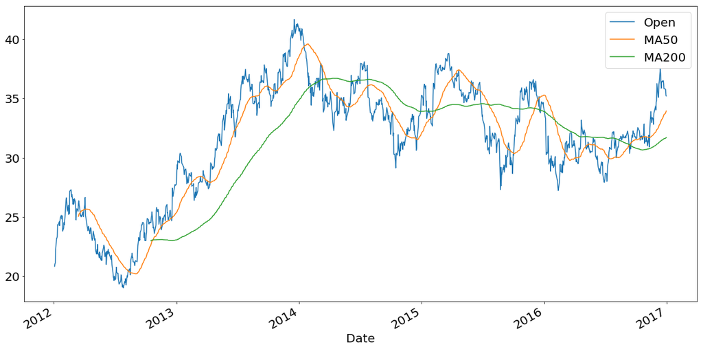

```python
gm_ticks['MA50'] = gm_ticks['Open'].rolling(50).mean()
gm_ticks['MA200'] = gm_ticks['Open'].rolling(200).mean()

gm_ticks[[
    'Open',
    'MA50',
    'MA200'
]].plot(figsize=(20, 10));
```

### Scatter Matrix

Visualising correlation between the Open prices of Tesla, Ford, and GM.

back to index

```python
from pandas.plotting import scatter_matrix
```

```python
all_ticks = pd.concat([
    tesla_ticks['Open'],
    ford_ticks['Open'],
    gm_ticks['Open']
], axis=1)

all_ticks.columns = ['Tesla Open', 'Ford Open', 'GM Open']
```

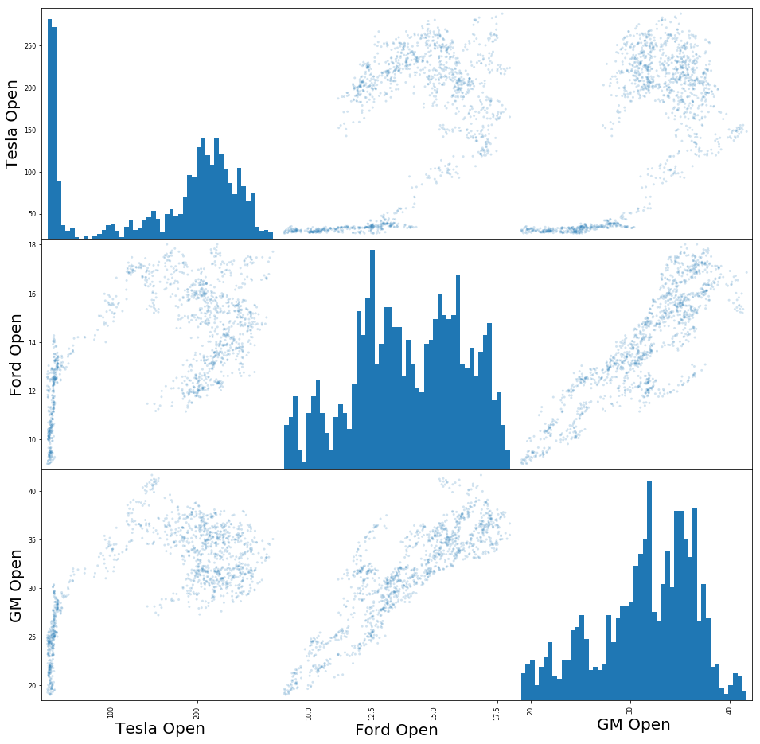

```python
scatter_matrix(
    all_ticks,
    figsize=(16, 16),
    alpha=0.2,
    hist_kwds={
        'bins': 50
    } # histogram keywords from matplotlib
);
```

### Candlestick Charts

Using [matplotlib.finance](https://matplotlib.org/examples/pylab_examples/finance_demo.html).

back to index

```python
from matplotlib.finance import candlestick_ohlc # Open, High, Low, Close
from matplotlib.dates import (
    DateFormatter,
    date2num,
    WeekdayLocator,
    DayLocator,
    MONDAY
)
```

```python
def make_candles(ticks, title, figsize, year_month):
    ticks_reset = ticks.loc[year_month].reset_index()
    ticks_reset['date_ax'] = ticks_reset['Date'].apply(
        lambda date: date2num(date)
    )

    columns = ['date_ax', 'Open', 'High', 'Low', 'Close']
    quotes = [tuple(vals) for vals in ticks_reset[columns].values]

    mondays = WeekdayLocator(MONDAY)        # major ticks on the mondays
    alldays = DayLocator()                  # minor ticks on the days
    weekFormatter = DateFormatter('%b %d')  # e.g., Jan 12
    dayFormatter = DateFormatter('%d')      # e.g., 12

    fig, ax = plt.subplots(figsize=figsize)
    fig.subplots_adjust(bottom=0.2)
    ax.xaxis.set_major_locator(mondays)
    ax.xaxis.set_minor_locator(alldays)
    ax.xaxis.set_major_formatter(weekFormatter)

    candlestick_ohlc(ax, quotes, width=0.6, colorup='g', colordown='r')

    plt.title(title);
```

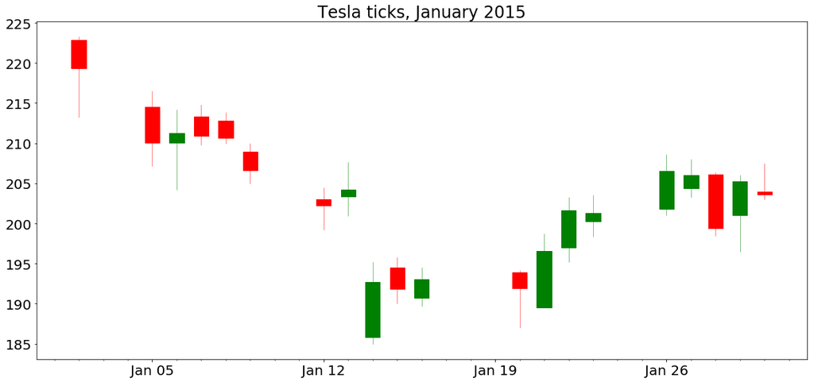

```python
make_candles(tesla_ticks, 'Tesla ticks, January 2015', (20, 10), '2015-01')
```

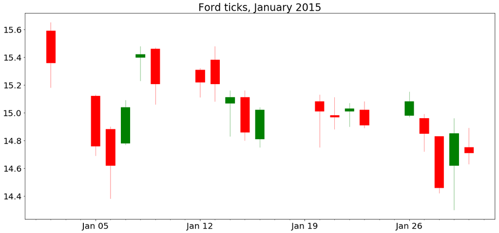

```python
make_candles(ford_ticks, 'Ford ticks, January 2015', (20, 10), '2015-01')
```

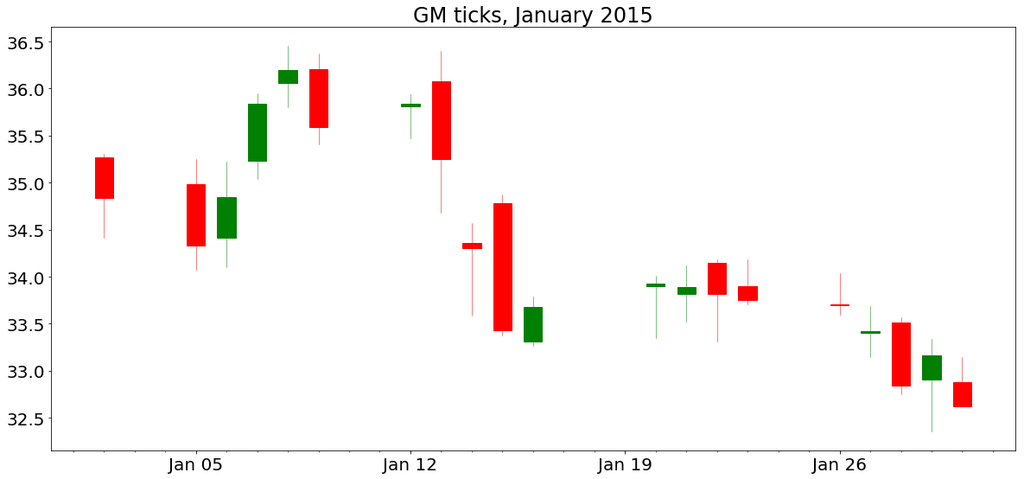

```python
make_candles(gm_ticks, 'GM ticks, January 2015', (20, 10), '2015-01')
```

## Basic Financial Analysis

### Daily Percentage Change

$ r_t = \frac{p_t}{p_{t-1}} -1$

If daily returns have a wide distribution, the stock is more volatile from one day to the next.

back to index

```python
# Manually
tesla_ticks['Returns'] = (
    tesla_ticks['Close'] / tesla_ticks['Close'].shift(1)
) - 1

# OR using Pandas in-built function
ford_ticks['Returns'] = ford_ticks['Close'].pct_change(1)
gm_ticks['Returns'] = gm_ticks['Close'].pct_change(1)
```

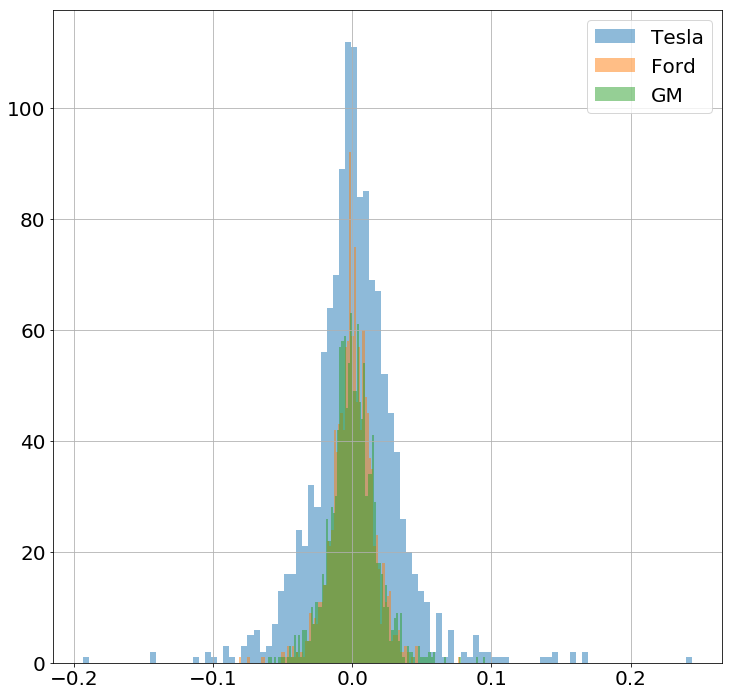

```python
tesla_ticks['Returns'].hist(
    figsize=(12, 12),
    bins=100,
    label='Tesla',
    alpha=0.5
)

ford_ticks['Returns'].hist(
    figsize=(12, 12),
    bins=100,
    label='Ford',
    alpha=0.5
)

gm_ticks['Returns'].hist(
    figsize=(12, 12),
    bins=100,
    label='GM',
    alpha=0.5
)

plt.legend();
```

### Kernel Density Estimation

Smoothes out the histograms of daily returns.

back to index

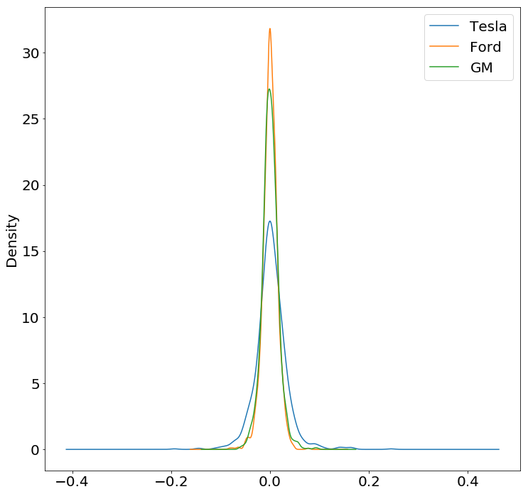

```python
tesla_ticks['Returns'].plot(
    kind='kde',
    figsize=(12, 12),
    label='Tesla',
)

ford_ticks['Returns'].plot(
    kind='kde',
    figsize=(12, 12),
    label='Ford',
)

gm_ticks['Returns'].plot(
    kind='kde',
    figsize=(12, 12),
    label='GM',
)

plt.legend();
```

### Box Plots of Daily Returns

back to index

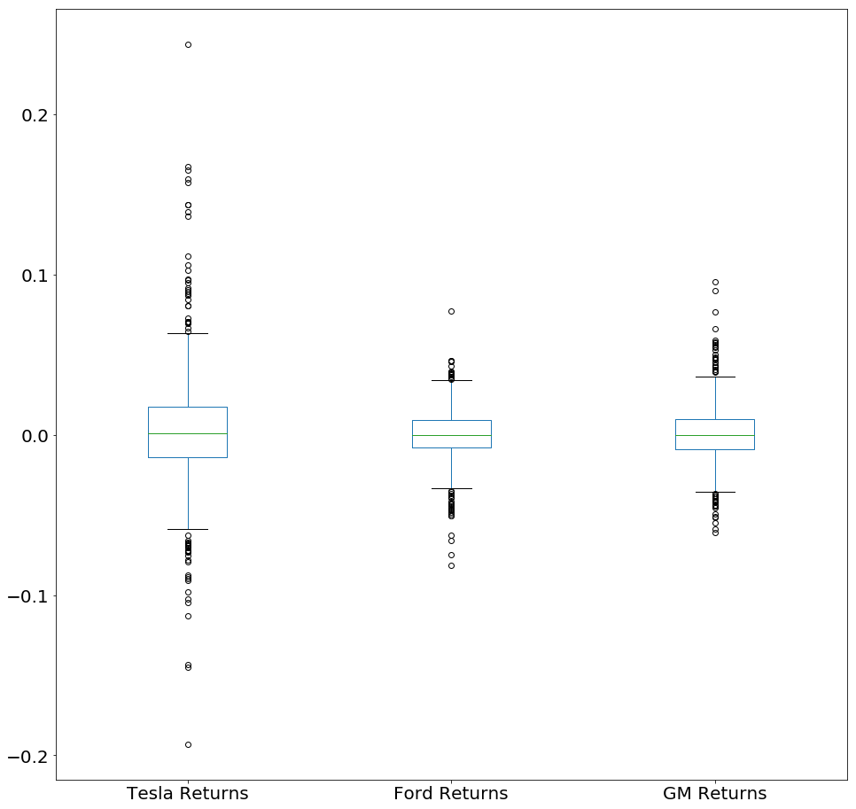

```python
box_df = pd.concat([
    tesla_ticks['Returns'],
    ford_ticks['Returns'],
    gm_ticks['Returns'],
], axis=1)

box_df.columns = ['Tesla Returns', 'Ford Returns', 'GM Returns']

box_df.plot(kind='box', figsize=(16, 16));
```

### Scatter Matrix of Daily Returns

Visualising correlation of daily returns between Tesla, Ford, and GM.

back to index

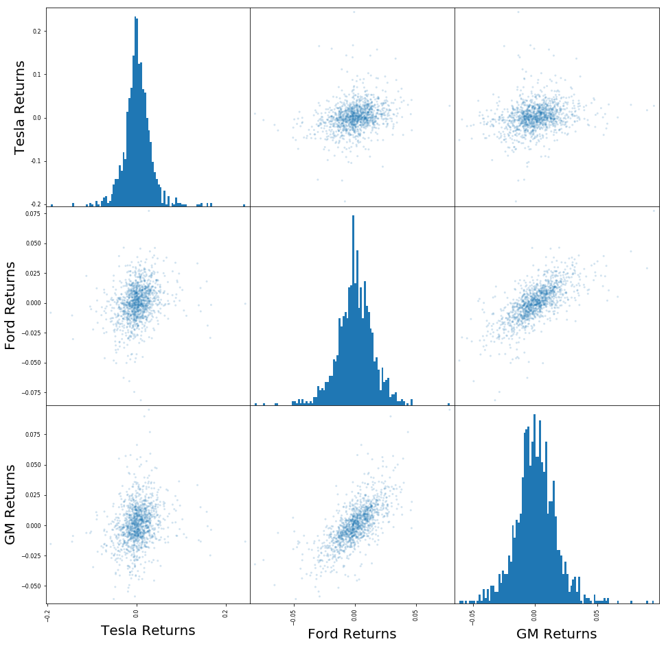

```python
scatter_matrix(
    box_df,
    figsize=(16, 16),
    alpha=0.2,
    hist_kwds={
        'bins': 100
    }
);
```

### Cumulative Return (CMR)

$ i_t = (1+r_t) * i_{t-1} $

where $ i_t $ - investment at time $ t $, $ r_t $ - return at time $ t $.

Aggregate amount an investment has gained or lost over time.

```python
for df in [tesla_ticks, ford_ticks, gm_ticks]:
    df['CMR'] = (1 + df['Returns']).cumprod()
```

[figure not shown]

```python
tesla_ticks['CMR'].plot(
    label='Tesla',
    figsize=(20, 10),
)

ford_ticks['CMR'].plot(
    label='Ford',
    figsize=(20, 10),
)

gm_ticks['CMR'].plot(
    label='GM',
    figsize=(20, 10),
)

plt.title('Cumulative Return (All)')
plt.legend();
```

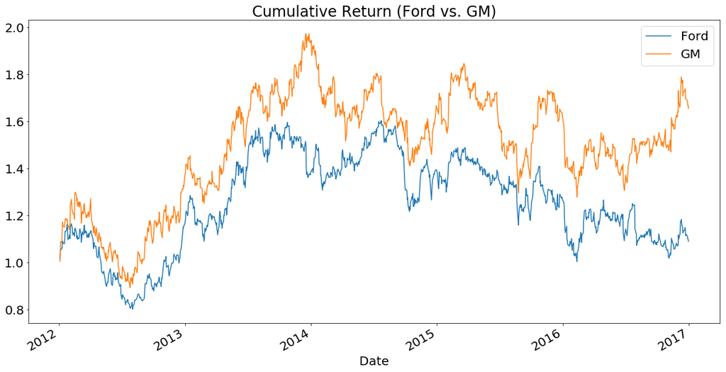

```python
ford_ticks['CMR'].plot(
    label='Ford',
    figsize=(20, 10),
)

gm_ticks['CMR'].plot(
    label='GM',
    figsize=(20, 10),
)

plt.title('Cumulative Return (Ford vs. GM)')
plt.legend();
```

back to index